# Homework 5 Peer Assessment

Spring Semester 2022

## Background

Selected molecular descriptors from the Dragon chemoinformatics application were used to predict bioconcentration factors for 779 chemicals in order to evaluate QSAR (Quantitative Structure Activity Relationship). This dataset was obtained from the UCI machine learning repository.

The dataset consists of 779 observations of 10 attributes. Below is a brief description of each feature and the response variable (logBCF) in our dataset:

1. *nHM* - number of heavy atoms (integer)
2. *piPC09* - molecular multiple path count (numeric)
3. *PCD* - difference between multiple path count and path count (numeric)
4. *X2Av* - average valence connectivity (numeric)
5. *MLOGP* - Moriguchi octanol-water partition coefficient (numeric)
6. *ON1V* - overall modified Zagreb index by valence vertex degrees (numeric)
7. *N.072* - Frequency of RCO-N< / >N-X=X fragments (integer)
8. *B02[C-N]* - Presence/Absence of C-N atom pairs (binary)
9. *F04[C-O]* - Frequency of C-O atom pairs (integer)
10. *logBCF* - Bioconcentration Factor in log units (numeric)

Note that all predictors with the exception of B02[C-N] are quantitative. For the purpose of this assignment, DO NOT CONVERT B02[C-N] to factor. Leave the data in its original format - numeric in R.

Please load the dataset “Bio_pred” and then split the dataset into a train and test set in a 80:20 ratio. Use the training set to build the models in Questions 1-6. Use the test set to help evaluate model performance in Question 7. Please make sure that you are using R version 3.6.X or above (i.e. version 4.X is also acceptable).

## Read Data

```r
#if (!require("CombMSC", character.only=TRUE)) {
#packageurl <- "https://cran.r-project.org/src/contrib/Archive/CombMSC/CombMSC_1.4.2.1.tar.gz"
#install.packages(packageurl, repos=NULL, type="source")
#library(CombMSC)
#}
```

```r
# Clear variables in memory
rm(list=ls())

# Import the libraries
library(CombMSC)
library(boot)
library(leaps)
library(MASS)
library(glmnet)

# Ensure that the sampling type is correct
RNGkind(sample.kind="Rejection")

# Set a seed for reproducibility
set.seed(100)

# Read data
fullData = read.csv("E:/Data/Bio_pred.csv",header=TRUE)

# Split data for traIning and testing
testRows = sample(nrow(fullData),0.2*nrow(fullData))
testData = fullData[testRows, ]
trainData = fullData[-testRows, ]
```

Note: Use the training set to build the models in Questions 1-6. Use the test set to help evaluate model performance in Question 7.

## Question 1: Full Model

1. Fit a multiple linear regression with the variable *logBCF* as the response and the other variables as predictors. Call it *model1*. Display the model summary.

```r
model1 <- lm(logBCF ~ ., data = trainData)
summary(model1)
```

```
##
## Call:
## lm(formula = logBCF ~ ., data = trainData)
##
## Residuals:
##     Min      1Q  Median      3Q     Max
## -3.2577 -0.5180  0.0448  0.5117  4.0423
##
## Coefficients:
##              Estimate Std. Error t value Pr(>|t|)
## (Intercept)  0.001422   0.138057   0.010  0.99179
## nHM          0.137022   0.022462   6.100 1.88e-09 ***
## piPC09       0.031158   0.020874   1.493  0.13603
## PCD          0.055655   0.063874   0.871  0.38391
## X2Av        -0.031890   0.253574  -0.126  0.89996
## MLOGP        0.506088   0.034211  14.793  < 2e-16 ***
## ON1V         0.140595   0.066810   2.104  0.03575 *
## N.072       -0.073334   0.070993  -1.033  0.30202
## B02.C.N.    -0.158231   0.080143  -1.974  0.04879 *
## F04.C.O.    -0.030763   0.009667  -3.182  0.00154 **
## ---
## Signif. codes:  0 '***' 0.001 '**' 0.01 '*' 0.05 '.' 0.1 ' ' 1
##
## Residual standard error: 0.7957 on 614 degrees of freedom
## Multiple R-squared:  0.6672, Adjusted R-squared:  0.6623
## F-statistic: 136.8 on 9 and 614 DF,  p-value: < 2.2e-16
```

2. Which regression coefficients are significant at the 95% confidence level? At the 99% confidence level?

   **Response:**

   nHM, MLOGP, ON1V, B02[C-N] and F04[C-O]. are significant at the 95% confidence level.

   nHM, MLOGP and F04[C-O]. are significant at the 99% confidence level.
3. What are the Mallow’s Cp, AIC, and BIC criterion values for this model?

```r
set.seed(100)

n = nrow(trainData)

#calculate CP
Cp(model1, S2=summary(model1)$sigma^2)
```

```
##      [,1]
## [1,]   10
```

```r
#Calculate AIC
AIC(model1, k=2)
```

```
## [1] 1497.477
```

```r
#Calculate BIC
AIC(model1, k=log(n))
```

```
## [1] 1546.274
```

**Response:**

The Mallow’s Cp equals 10. AIC equals 1497.477 . BIC equals 1546.274 .

4. Build a new model on the training data with only the variables which coefficients were found to be statistically significant at the 99% confident level. Call it *model2*. Perform a Partial F-test to compare this new model with the full model (*model1*). Which one would you prefer? Is it good practice to select variables based on statistical significance of individual coefficients? Explain.

```r
set.seed(100)

model2 <- lm(logBCF ~ nHM + MLOGP + F04.C.O., data = trainData)
summary(model2)
```

```
##
## Call:
## lm(formula = logBCF ~ nHM + MLOGP + F04.C.O., data = trainData)
##
## Residuals:
##     Min      1Q  Median      3Q     Max
## -3.2555 -0.5097  0.0374  0.5471  4.2704
##
## Coefficients:
##             Estimate Std. Error t value Pr(>|t|)
## (Intercept) -0.03076    0.07836  -0.393   0.6948
## nHM          0.10948    0.01762   6.213 9.56e-10 ***
## MLOGP        0.60993    0.02177  28.018  < 2e-16 ***
## F04.C.O.    -0.01295    0.00745  -1.738   0.0826 .
## ---
## Signif. codes:  0 '***' 0.001 '**' 0.01 '*' 0.05 '.' 0.1 ' ' 1
##
## Residual standard error: 0.8037 on 620 degrees of freedom
## Multiple R-squared:  0.6571, Adjusted R-squared:  0.6554
## F-statistic:   396 on 3 and 620 DF,  p-value: < 2.2e-16
```

```r
anova(model1, model2)
```

```
## Analysis of Variance Table
##
## Model 1: logBCF ~ nHM + piPC09 + PCD + X2Av + MLOGP + ON1V + N.072 + B02.C.N. +
##     F04.C.O.
## Model 2: logBCF ~ nHM + MLOGP + F04.C.O.
##   Res.Df    RSS Df Sum of Sq     F  Pr(>F)
## 1    614 388.70
## 2    620 400.51 -6   -11.809 3.109 0.00523 **
## ---
## Signif. codes:  0 '***' 0.001 '**' 0.01 '*' 0.05 '.' 0.1 ' ' 1
```

**Response:**

I prefer model1, because:

1. Both the R-squared and adjusted R-squared value in model1 are slightly higher than model2. This means that model1 can explain more variations in the response variable than model2.
2. The partial F-test (ANOVA) shows a p-value equal to 0.00523 (smaller than 0.01) . This means that at least one of those variables excluded from model2 can add explanatory power to the model (at the confidence level of 99%) . Therefore, it is not appropriate to exclude all these variables from the model.

It is not a good practice to select variables based on statistical significance of individual coefficients. In the full model, the significant variables show high statistical significance, given other variables in the model. It can not be guaranteed that these variables are still significant after other variables are excluded from the model. For example, in model1, F04[C-O] is significant at the confidence level of 99%, but in model2, it is not significant at the level of 99% .

## Question 2: Full Model Search

1. Compare all possible models using Mallow’s Cp. How many models can be constructed using subsets/combinations drawn from the full set of variables? Display a table indicating the variables included in the best model of each size and the corresponding Mallow’s Cp value.

Hint: You can use nbest parameter.

```r
set.seed(100)

# calculate number of subsets
out <- leaps(trainData[,-c(10)], trainData[,10], method = "Cp")
nrow(out$which)
```

```
## [1] 79
```

```r
# best model of each size
out <- leaps(trainData[,-c(10)], trainData[,10], method = "Cp", nbest = 1)
cbind(as.matrix(out$which),out$Cp)
```

```
##   1 2 3 4 5 6 7 8 9
## 1 0 0 0 0 1 0 0 0 0 58.596851
## 2 1 0 0 0 1 0 0 0 0 17.737801
## 3 1 1 0 0 1 0 0 0 0 15.184626
## 4 1 1 0 0 1 0 0 0 1  9.495041
## 5 1 1 0 0 1 0 0 1 1  7.240754
## 6 1 1 0 0 1 1 0 1 1  6.116174
## 7 1 1 0 0 1 1 1 1 1  6.831852
## 8 1 1 1 0 1 1 1 1 1  8.015816
## 9 1 1 1 1 1 1 1 1 1 10.000000
```

**Response:**

79 models can be constructed using subsets/combinations drawn from the full set of variables. The table showing the best model of each size and the corresponding Mallow’s Cp value is displayed above.

2. How many variables are in the model with the lowest Mallow’s Cp value? Which variables are they? Fit this model and call it *model3*. Display the model summary.

```r
set.seed(100)

best_model <- which(out$Cp == min(out$Cp))
var_selection <- as.matrix(out$which)[best_model, ]

colnames(trainData[, -10])[var_selection]
```

```
## [1] "nHM"      "piPC09"   "MLOGP"    "ON1V"     "B02.C.N." "F04.C.O."
```

```r
model3 <- lm(logBCF ~ nHM + piPC09 + MLOGP + ON1V + B02.C.N. + F04.C.O.,
             data = trainData)
summary(model3)
```

```
##
## Call:
## lm(formula = logBCF ~ nHM + piPC09 + MLOGP + ON1V + B02.C.N. +
##     F04.C.O., data = trainData)
##
## Residuals:
##     Min      1Q  Median      3Q     Max
## -3.2364 -0.5234  0.0421  0.5196  4.1159
##
## Coefficients:
##              Estimate Std. Error t value Pr(>|t|)
## (Intercept)  0.035785   0.099454   0.360  0.71911
## nHM          0.124086   0.019083   6.502 1.63e-10 ***
## piPC09       0.042167   0.014135   2.983  0.00297 **
## MLOGP        0.528522   0.029434  17.956  < 2e-16 ***
## ON1V         0.098099   0.055457   1.769  0.07740 .
## B02.C.N.    -0.160204   0.073225  -2.188  0.02906 *
## F04.C.O.    -0.028644   0.009415  -3.042  0.00245 **
## ---
## Signif. codes:  0 '***' 0.001 '**' 0.01 '*' 0.05 '.' 0.1 ' ' 1
##
## Residual standard error: 0.7951 on 617 degrees of freedom
## Multiple R-squared:  0.666,  Adjusted R-squared:  0.6628
## F-statistic: 205.1 on 6 and 617 DF,  p-value: < 2.2e-16
```

**Response:**

Six variables are in the model with the lowest Mallow’s Cp value. They are nHM, piPC09, MLOGP, ON1V, B02.C.N. and F04.C.O.

## Question 3: Stepwise Regression

1. Perform backward stepwise regression using BIC. Allow the minimum model to be the model with only an intercept, and the full model to be *model1*. Display the model summary of your final model. Call it *model4*

```r
set.seed(100)

n = nrow(trainData)

minimum_model = lm(logBCF ~ 1, data = trainData)
model4 <- step(model1, scope=list(lower=minimum_model,
                                  upper=model1),
               direction="backward", k = log(n))
```

```
## Start:  AIC=-231
## logBCF ~ nHM + piPC09 + PCD + X2Av + MLOGP + ON1V + N.072 + B02.C.N. +
##     F04.C.O.
##
##            Df Sum of Sq    RSS      AIC
## - X2Av      1     0.010 388.71 -237.417
## - PCD       1     0.481 389.18 -236.662
## - N.072     1     0.676 389.38 -236.350
## - piPC09    1     1.411 390.11 -235.173
## - B02.C.N.  1     2.468 391.17 -233.484
## - ON1V      1     2.804 391.51 -232.949
## <none>                  388.70 -230.997
## - F04.C.O.  1     6.410 395.11 -227.226
## - nHM       1    23.557 412.26 -200.718
## - MLOGP     1   138.539 527.24  -47.211
##
## Step:  AIC=-237.42
## logBCF ~ nHM + piPC09 + PCD + MLOGP + ON1V + N.072 + B02.C.N. +
##     F04.C.O.
##
##            Df Sum of Sq    RSS      AIC
## - PCD       1     0.517 389.23 -243.025
## - N.072     1     0.667 389.38 -242.783
## - piPC09    1     1.423 390.14 -241.574
## - B02.C.N.  1     2.510 391.22 -239.838
## - ON1V      1     2.915 391.63 -239.192
## <none>                  388.71 -237.417
## - F04.C.O.  1     6.491 395.21 -233.520
## - nHM       1    25.431 414.15 -204.309
## - MLOGP     1   146.081 534.80  -44.772
##
## Step:  AIC=-243.02
## logBCF ~ nHM + piPC09 + MLOGP + ON1V + N.072 + B02.C.N. + F04.C.O.
##
##            Df Sum of Sq    RSS      AIC
## - N.072     1     0.813 390.04 -248.159
## - B02.C.N.  1     2.099 391.33 -246.105
## - ON1V      1     2.412 391.64 -245.606
## <none>                  389.23 -243.025
## - F04.C.O.  1     6.088 395.32 -239.776
```

[output cut: 21 more lines]

```
## - F04.C.O.  1     3.902 395.92 -251.695
## <none>                  392.02 -251.438
## - piPC09    1     7.252 399.27 -246.437
## - nHM       1    25.197 417.22 -219.003
## - MLOGP     1   247.006 639.03   47.031
##
## Step:  AIC=-253.6
## logBCF ~ nHM + piPC09 + MLOGP + F04.C.O.
##
##            Df Sum of Sq    RSS      AIC
## <none>                  394.72 -253.602
## - F04.C.O.  1     4.868 399.58 -252.390
## - piPC09    1     5.798 400.51 -250.939
## - nHM       1    26.847 421.56 -218.977
## - MLOGP     1   302.931 697.65   95.359
```

```r
summary(model4)
```

```
##
## Call:
## lm(formula = logBCF ~ nHM + piPC09 + MLOGP + F04.C.O., data = trainData)
##
## Residuals:
##     Min      1Q  Median      3Q     Max
## -3.2611 -0.5126  0.0517  0.5353  4.3488
##
## Coefficients:
##              Estimate Std. Error t value Pr(>|t|)
## (Intercept) -0.008695   0.078196  -0.111  0.91150
## nHM          0.114029   0.017574   6.489 1.78e-10 ***
## piPC09       0.041119   0.013636   3.015  0.00267 **
## MLOGP        0.566473   0.025990  21.796  < 2e-16 ***
## F04.C.O.    -0.022104   0.008000  -2.763  0.00590 **
## ---
## Signif. codes:  0 '***' 0.001 '**' 0.01 '*' 0.05 '.' 0.1 ' ' 1
##
## Residual standard error: 0.7985 on 619 degrees of freedom
## Multiple R-squared:  0.662,  Adjusted R-squared:  0.6599
## F-statistic: 303.1 on 4 and 619 DF,  p-value: < 2.2e-16
```

2. How many variables are in *model4*? Which regression coefficients are significant at the 99% confidence level?

   **Response:**

   Four variables are in model4. They are nHM, PiPC090, MLOGP and F04[C-O] . The coefficients of all the four variables are significant.
3. Perform forward stepwise selection with AIC. Allow the minimum model to be the model with only an intercept, and the full model to be *model1*. Display the model summary of your final model. Call it *model5*. Do the variables included in *model5* differ from the variables in *model4*?

```r
set.seed(100)

model5 <- step(minimum_model, scope=list(lower=minimum_model,
                                         upper=model1),
               direction="forward", k = 2)
```

```
## Start:  AIC=393.14
## logBCF ~ 1
##
##            Df Sum of Sq     RSS     AIC
## + MLOGP     1    738.32  429.60 -228.94
## + nHM       1    255.66  912.25  240.98
## + piPC09    1    220.90  947.02  264.31
## + PCD       1    150.75 1017.17  308.90
## + B02.C.N.  1    139.23 1028.68  315.93
## + N.072     1     43.55 1124.37  371.43
## + ON1V      1     27.76 1140.16  380.13
## + F04.C.O.  1     20.79 1147.13  383.93
## <none>                  1167.92  393.14
## + X2Av      1      2.45 1165.46  393.83
##
## Step:  AIC=-228.94
## logBCF ~ MLOGP
##
##            Df Sum of Sq    RSS     AIC
## + nHM       1   27.1327 402.47 -267.65
## + B02.C.N.  1    4.1778 425.42 -233.04
## + F04.C.O.  1    4.1526 425.45 -233.00
## + X2Av      1    3.2819 426.32 -231.72
## + ON1V      1    2.3664 427.23 -230.38
## <none>                  429.60 -228.94
## + piPC09    1    1.0443 428.55 -228.46
## + N.072     1    0.2481 429.35 -227.30
## + PCD       1    0.1198 429.48 -227.11
##
## Step:  AIC=-267.65
## logBCF ~ MLOGP + nHM
##
##            Df Sum of Sq    RSS     AIC
## + piPC09    1   2.88247 399.58 -270.13
## + F04.C.O.  1   1.95225 400.51 -268.68
## + B02.C.N.  1   1.93200 400.53 -268.65
## <none>                  402.47 -267.65
## + PCD       1   1.23679 401.23 -267.57
## + N.072     1   0.40989 402.06 -266.29
## + ON1V      1   0.33115 402.13 -266.16
```

[output cut: 28 more lines]

```
##         Df Sum of Sq    RSS     AIC
## + ON1V   1   1.97807 390.04 -279.21
## <none>               392.02 -278.06
## + N.072  1   0.37905 391.64 -276.66
## + X2Av   1   0.12543 391.90 -276.25
## + PCD    1   0.00000 392.02 -276.06
##
## Step:  AIC=-279.21
## logBCF ~ MLOGP + nHM + piPC09 + F04.C.O. + B02.C.N. + ON1V
##
##         Df Sum of Sq    RSS     AIC
## <none>               390.04 -279.21
## + N.072  1   0.81306 389.23 -278.51
## + PCD    1   0.66238 389.38 -278.27
## + X2Av   1   0.02794 390.02 -277.26
```

```r
summary(model5)
```

```
##
## Call:
## lm(formula = logBCF ~ MLOGP + nHM + piPC09 + F04.C.O. + B02.C.N. +
##     ON1V, data = trainData)
##
## Residuals:
##     Min      1Q  Median      3Q     Max
## -3.2364 -0.5234  0.0421  0.5196  4.1159
##
## Coefficients:
##              Estimate Std. Error t value Pr(>|t|)
## (Intercept)  0.035785   0.099454   0.360  0.71911
## MLOGP        0.528522   0.029434  17.956  < 2e-16 ***
## nHM          0.124086   0.019083   6.502 1.63e-10 ***
## piPC09       0.042167   0.014135   2.983  0.00297 **
## F04.C.O.    -0.028644   0.009415  -3.042  0.00245 **
## B02.C.N.    -0.160204   0.073225  -2.188  0.02906 *
## ON1V         0.098099   0.055457   1.769  0.07740 .
## ---
## Signif. codes:  0 '***' 0.001 '**' 0.01 '*' 0.05 '.' 0.1 ' ' 1
##
## Residual standard error: 0.7951 on 617 degrees of freedom
## Multiple R-squared:  0.666,  Adjusted R-squared:  0.6628
## F-statistic: 205.1 on 6 and 617 DF,  p-value: < 2.2e-16
```

**Response:**

The variables included in model5 is different from model4. B02[C-N] and ON1V are included in model5, but they are not included in model4.

4. Compare the adjusted $R^2$, Mallow’s Cp, AICs and BICs of the full model (*model1*), the model found in Question 2 (*model3*), and the model found using backward selection with BIC (*model4*). Which model is preferred based on these criteria and why?

```r
set.seed(100)

model_compare <- data.frame(
  Model = c(1,3,4),
  Adj.R.Squared = c(summary(model1)$adj.r.squared,
                    summary(model3)$adj.r.squared,
                    summary(model4)$adj.r.squared),
  Cp = c(Cp(model1, S2=summary(model1)$sigma^2),
         Cp(model3, S2=summary(model3)$sigma^2),
         Cp(model4, S2=summary(model4)$sigma^2)),
  AIC = c(AIC(model1, k=2),
          AIC(model3, k=2),
          AIC(model4, k=2)),
  BIC = c(AIC(model1, k=log(n)),
          AIC(model3, k=log(n)),
          AIC(model4, k=log(n)))
)

model_compare
```

```
##   Model Adj.R.Squared Cp      AIC      BIC
## 1     1     0.6623027 10 1497.477 1546.274
## 2     3     0.6627864  7 1493.623 1529.113
## 3     4     0.6598504  5 1497.052 1523.669
```

**Response:**

Model3 and Model4 are preferred over model1.

Model3 is the best model according to AIC, while model4 is the best model according to BIC. At the meantime, model4 also has the lowest Cp value, which means that model4 has the lowest complexity and is the easiest one to interpret.

It makes sense to further compare the performance of model3 and model4 by using cross validation.

## Question 4: Ridge Regression

1. Perform ridge regression on the training set. Use cv.glmnet() to find the lambda value that minimizes the cross-validation error using 10 fold CV.

```r
set.seed(100)

predictors = as.matrix(trainData[ , 1:9])
logBCF = trainData$logBCF

# perform ridge regression
ridge.cv <- cv.glmnet(predictors, logBCF, alpha=0, nfolds=10)

best_lambda <- ridge.cv$lambda.min
best_lambda
```

```
## [1] 0.108775
```

**Response:**

The lambda value that minimizes the cross-validation error using 10 fold CV equals 0.108775

2. List the value of coefficients at the optimum lambda value.

```r
set.seed(100)

ridge <- glmnet(predictors, logBCF, alpha=0, nfolds=10)
coef(ridge, s=ridge.cv$lambda.min)
```

```
## 10 x 1 sparse Matrix of class "dgCMatrix"
##                      s1
## (Intercept)  0.13841426
## nHM          0.14391877
## piPC09       0.03735762
## PCD          0.08235334
## X2Av        -0.06901352
## MLOGP        0.44403655
## ON1V         0.15770114
## N.072       -0.09683534
## B02.C.N.    -0.20919397
## F04.C.O.    -0.03177144
```

3. How many variables were selected? Was this result expected? Explain.

   **Response:**

   All nine variables are selected. This result is expected because ridge regression should not be used as a variable selection method. Ridge regression will let the coefficients shrink towards zero, but it will not force the coefficients to equal to zero.

## Question 5: Lasso Regression

1. Perform lasso regression on the training set.Use cv.glmnet() to find the lambda value that minimizes the cross-validation error using 10 fold CV.

```r
set.seed(100)

# perform lasso regression
lasso.cv <- cv.glmnet(predictors, logBCF, alpha=1, nfolds=10)

best_lambda <- lasso.cv$lambda.min
best_lambda
```

```
## [1] 0.007854436
```

**Response:**

The lambda value that minimizes the cross-validation error using 10 fold CV equals 0.007854436

2. Plot the regression coefficient path.

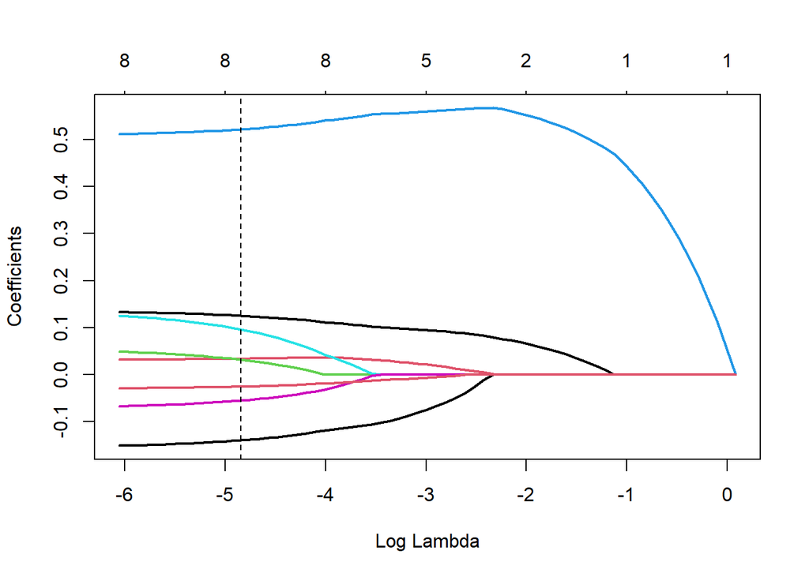

```r
set.seed(100)

lasso = glmnet(predictors, logBCF, alpha = 1, nlambda=100)

plot(lasso,xvar="lambda", lwd=2)
abline(v=log(lasso.cv$lambda.min), col='black', lty=2)
```

3. How many variables were selected? Which are they?

```r
set.seed(100)

coef(lasso, s=lasso.cv$lambda.min)
```

```
## 10 x 1 sparse Matrix of class "dgCMatrix"
##                      s1
## (Intercept)  0.02722838
## nHM          0.12543866
## piPC09       0.03387665
## PCD          0.03194878
## X2Av         .
## MLOGP        0.52174346
## ON1V         0.09633951
## N.072       -0.05487196
## B02.C.N.    -0.13961811
## F04.C.O.    -0.02535576
```

**Response:**

Eight variables are selected. They are: nHM, piPC09, PCD, MLOGP, ON1V, N.072, B02[C-N] and F04[C-O] .

## Question 6: Elastic Net

1. Perform elastic net regression on the training set. Use cv.glmnet() to find the lambda value that minimizes the cross-validation error using 10 fold CV. Give equal weight to both penalties.

```r
set.seed(100)

elastic.cv <- cv.glmnet(predictors, logBCF, alpha=0.5, nfolds=10)

best_lambda <- elastic.cv$lambda.min
best_lambda
```

```
## [1] 0.0207662
```

2. List the coefficient values at the optimal lambda. How many variables were selected? How do these variables compare to those from Lasso in Question 5?

```r
set.seed(100)

elastic = glmnet(predictors, logBCF, alpha=0.5, nlambda = 100)
coef(elastic, s = elastic.cv$lambda.min)
```

```
## 10 x 1 sparse Matrix of class "dgCMatrix"
##                      s1
## (Intercept)  0.04903516
## nHM          0.12397290
## piPC09       0.03470891
## PCD          0.03060034
## X2Av         .
## MLOGP        0.51776470
## ON1V         0.08901088
## N.072       -0.05236840
## B02.C.N.    -0.14155538
## F04.C.O.    -0.02420217
```

**Response:**

Eight variables are selected. They are the same variables selected by LASSO regression.

## Question 7: Model comparison

1. Predict *logBCF* for each of the rows in the test data using the full model, and the models found using backward stepwise regression with BIC, ridge regression, lasso regression, and elastic net. Display the first few predictions for each model.

```r
set.seed(100)

# create new predictor matrix
new_predictor <- as.matrix(testData[ , 1:9])

# full model
pred_full <- predict(model1, newdata = testData)
cat("Predictions for full model: \n\n")
```

```
## Predictions for full model:
```

```r
head(pred_full)
```

```
##      714      503      358      624      718      470
## 2.446479 4.333759 3.266892 1.664770 1.955362 4.333278
```

```r
# backward stepwise regression with BIC
pred_backward <- predict(model4, newdata = testData)
cat("Predictions for model found using backward stepwise regression with BIC: \n\n")
```

```
## Predictions for model found using backward stepwise regression with BIC:
```

```r
head(pred_backward)
```

```
##      714      503      358      624      718      470
## 2.424916 4.353167 3.274192 1.297175 2.001399 4.355470
```

```r
# Ridge regression
pred_ridge <- predict(ridge, newx = new_predictor, s=ridge.cv$lambda.min)
cat("Predictions for model found using ridge regression : \n\n")
```

```
## Predictions for model found using ridge regression :
```

```r
head(pred_ridge)
```

```
##           s1
## 714 2.454878
## 503 4.234425
## 358 3.223166
## 624 1.734094
## 718 1.993967
## 470 4.233222
```

```r
# Lasso & Elastic net
#Retrain the model
lasso.retrain <- lm(logBCF ~ nHM + piPC09 + PCD + MLOGP + ON1V +
                             N.072 + B02.C.N. + F04.C.O. ,
                    data = trainData)
pred_lasso <- predict(lasso.retrain, newdata = testData)

cat("Predictions for model found using lasso regression : \n\n")
```

```
## Predictions for model found using lasso regression :
```

```r
head(pred_lasso)
```

```
##      714      503      358      624      718      470
## 2.446392 4.333415 3.267254 1.658446 1.956798 4.332888
```

```r
cat("Predictions for model found using elastic net (same as predictions by lasso regression) : \n\n")
```

```
## Predictions for model found using elastic net (same as predictions by lasso regression) :
```

```r
pred_elastic <- pred_lasso
head(pred_elastic)
```

```
##      714      503      358      624      718      470
## 2.446392 4.333415 3.267254 1.658446 1.956798 4.332888
```

2. Compare the predictions using mean squared prediction error. Which model performed the best?

```r
set.seed(100)

# full model
MSPE_full <- mean((pred_full - testData$logBCF)^2)
cat("MSPE of full model:", MSPE_full, "\n")
```

```
## MSPE of full model: 0.5839296
```

```r
# backward stepwise regression with BIC
MSPE_backward <- mean((pred_backward - testData$logBCF)^2)
cat("MSPE of model found using backward stepwise regression with BICl: ",MSPE_backward, "\n")
```

```
## MSPE of model found using backward stepwise regression with BICl:  0.5742198
```

```r
# ridge regression
MSPE_ridge <- mean((pred_ridge - testData$logBCF)^2)
cat("MSPE of ridge regression: ",MSPE_ridge, "\n")
```

```
## MSPE of ridge regression:  0.5877835
```

```r
# lasso regression
MSPE_lasso <- mean((pred_lasso - testData$logBCF)^2)
cat("MSPE of lasso regression: ", MSPE_lasso, "\n")
```

```
## MSPE of lasso regression:  0.583547
```

```r
# elastic net
MSPE_elastic <- mean((pred_elastic - testData$logBCF)^2)
cat("MSPE of lasso regression: ",MSPE_elastic,"\n")
```

```
## MSPE of lasso regression:  0.583547
```

**Response:**

From the results above, the model found using backward stepwise regression with BIC performs the best.

3. Provide a table listing each method described in Question 7a and the variables selected by each method (see Lesson 5.8 for an example). Which variables were selected consistently?

|  | Backward Stepwise | Ridge | Lasso | Elastic Net |
| --- | --- | --- | --- | --- |
| nHM | x | x | x | x |
| piPC09 | x | x | x | x |
| PCD |  | x | x | x |
| X2AV |  | x |  |  |
| MLOGP | x | x | x | x |
| ON1V |  | x | x | x |
| N.072 |  | x | x | x |
| B02.C.N. |  | x | x | x |
| F04.C.O. | x | x | x | x |

**Response:**

nHM, piPc09, MLOGP and F04.C.O. are selected consistently.